# MA615_Midterm_ioSlides

10/21/2019

## Indicators:

**GNI per capita (Atlas $):**  
It is the gross national income, converted to U.S. dollars using the World Bank Atlas method, divided by the midyear population.

**Access to electricity (% of population):**  
It is the percentage of population with access to electricity. Electrification data are collected from industry, national surveys and international sources.

**Urban population (% of total population):**  
It refers to people living in urban areas as defined by national statistical offices. The data are collected and smoothed by United Nations Population Division.

## **Research Question:**

Is there a correlation between GNI per capita and access to electricity? How strond is the correlation?

And how about GNI per capita and urban population? How strong the correlation is?

## Get Data

First we search and load updated lists of inidicators: GNI per capita, access to electricity and urban population.

## Clean Up

## Dataframe Combining & Data Cleaning

Next we assign a dataframe with combining the three indicators, and then we select their corresponding data and assign to each indicator name; next we use na.omit to returns the non-missing value objects to clean the raw data.

```
##  [1] "iso2c"             "country"           "year"
##  [4] "NY.GNP.PCAP.CD"    "EG.ELC.ACCS.ZS"    "SP.URB.TOTL.IN.ZS"
##  [7] "iso3c"             "region"            "capital"
## [10] "longitude"         "latitude"          "income"
## [13] "lending"
```

```
##  [1] "iso2c"            "country"          "year"
##  [4] "GNI"              "Electricity"      "Urban_Population"
##  [7] "iso3c"            "region"           "capital"
## [10] "longitude"        "latitude"         "income"
## [13] "lending"
```

## Plot Graphs

Observe the summary and distribution of these three indicators: the mode of GNI concentrates in 0 to 10,000; the mode of Electricity concentrates in 90 to 100; and the distribution of Urban Population looks comparatively more average than the other two.

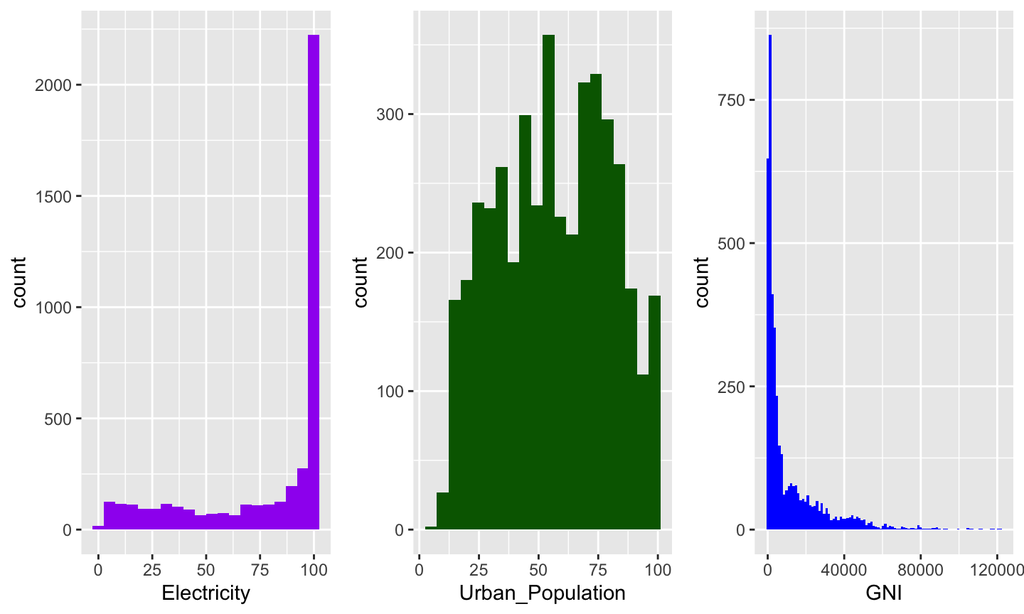

## Data Transformation

Worldwide Development

[output not shown]

## Scatter Plots

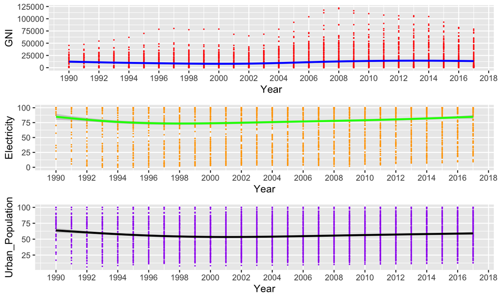

### From the above scatter plots, from 1990 to 2017, we can see there is no obvious flunctuation from GNI (mean), while the maximum fluctuates from 50,000 to 125,000; the electricity varies from 75% to 88%; and the urban population varies from 50% to 63%.

## Linear Regression & Correlation

### Plot Urban Population vs. GNI per Capita.

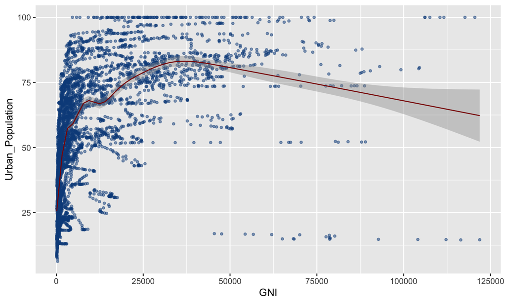

From the above plot we can tell that there is no direct correlation between GNI and Urban Population. While the urban population keep increasing with GNI increasing from 0 to 30,000, and it decreases when GNI gets larger than 30,000 (less than 125,000).

## Linear Regression & Correlation

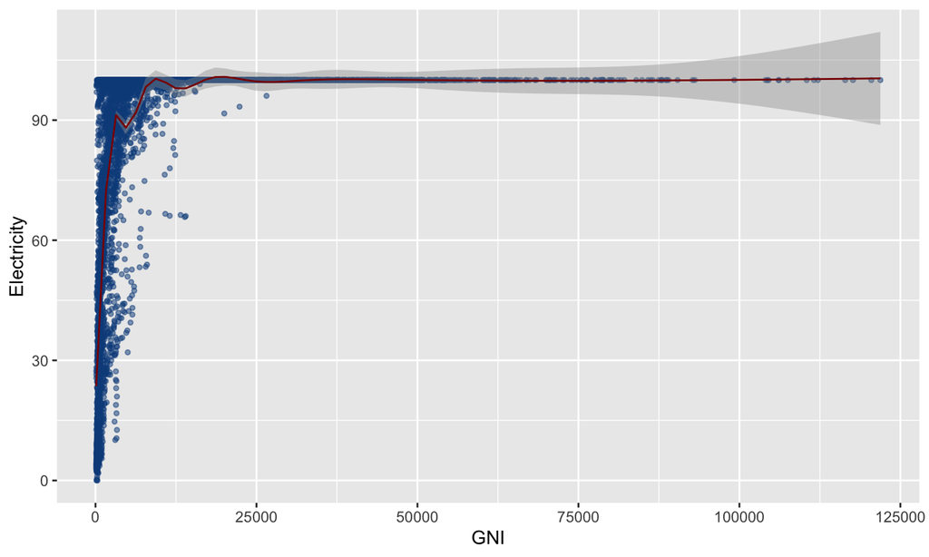